# Multi-Class Tabular Model for Date Fruits Classification Using Python and XGBoost

### January 4, 2023

SUMMARY: The project aims to construct a predictive model using various machine learning algorithms and document the end-to-end steps using a template. The Date Fruits Dataset is a multi-class modeling situation where we attempt to predict one of several (more than two) possible outcomes.

INTRODUCTION: Many factors determine the type of fruit with external appearance features such as color, length, diameter, and shape. However, classifying the variety of fruits simply by looking at their outward appearance requires expertise and a great effort and is also time-consuming. This study aims to classify the types of date fruit using machine-learning methods. The research team obtained 898 images of seven different date fruit types for this project via a computer vision system. The research team was hopeful that machine learning methods could successfully classify date fruit types.

ANALYSIS: The performance of the preliminary XGBoost model achieved an accuracy benchmark of 89.41%. After a series of tuning trials, the final model processed the training dataset with an accuracy score of 90.75%.

CONCLUSION: In this iteration, the XGBoost model appeared to be a suitable algorithm for modeling this dataset.

Dataset Used: Date Fruits Dataset

Dataset ML Model: Multi-Class classification with numerical features

Dataset Reference: https://www.muratkoklu.com/datasets/

One source of potential performance benchmarks: https://doi.org/10.1155/2021/4793293

## Task 1 - Prepare Environment

```python
# Retrieve the GPU information
gpu_info = !nvidia-smi
gpu_info = '\n'.join(gpu_info)
print(gpu_info)
```

```
Sun Jan  1 00:47:19 2023
+-----------------------------------------------------------------------------+
| NVIDIA-SMI 460.32.03    Driver Version: 460.32.03    CUDA Version: 11.2     |
|-------------------------------+----------------------+----------------------+
| GPU  Name        Persistence-M| Bus-Id        Disp.A | Volatile Uncorr. ECC |
| Fan  Temp  Perf  Pwr:Usage/Cap|         Memory-Usage | GPU-Util  Compute M. |
|                               |                      |               MIG M. |
|===============================+======================+======================|
|   0  A100-SXM4-40GB      Off  | 00000000:00:04.0 Off |                    0 |
| N/A   30C    P0    55W / 400W |      0MiB / 40536MiB |      0%      Default |
|                               |                      |             Disabled |
+-------------------------------+----------------------+----------------------+

+-----------------------------------------------------------------------------+
| Processes:                                                                  |
|  GPU   GI   CI        PID   Type   Process name                  GPU Memory |
|        ID   ID                                                   Usage      |
|=============================================================================|
|  No running processes found                                                 |
+-----------------------------------------------------------------------------+
```

```python
# Retrieve the memory configuration
from psutil import virtual_memory
ram_gb = virtual_memory().total / 1e9
print('Your runtime has {:.1f} gigabytes of available RAM\n'.format(ram_gb))
```

```
Your runtime has 89.6 gigabytes of available RAM
```

```python
# Retrieve the CPU information
ncpu = !nproc
print("The number of available CPUs is:", ncpu[0])
```

```
The number of available CPUs is: 12
```

### 1.a) Load libraries and modules

```python
# Set the random seed number for reproducible results
RNG_SEED = 888
```

```python
import numpy as np
import pandas as pd
import seaborn as sns
import matplotlib.pyplot as plt
import os
import sys
import math
# import boto3
import zipfile
import urllib
from datetime import datetime
from sklearn import preprocessing
from sklearn.model_selection import train_test_split
from sklearn.model_selection import StratifiedKFold
from sklearn.model_selection import cross_val_score
from sklearn.model_selection import GridSearchCV
from sklearn.metrics import classification_report
from sklearn.metrics import confusion_matrix
from sklearn.metrics import accuracy_score
from sklearn.pipeline import Pipeline
from sklearn import compose
from sklearn import impute

# from sklearn.feature_selection import RFE
# from imblearn.pipeline import Pipeline
# from imblearn.over_sampling import SMOTE
# from imblearn.under_sampling import RandomUnderSampler

from xgboost import XGBClassifier
```

### 1.b) Set up the controlling parameters and functions

```python
# Begin the timer for the script processing
START_TIME_SCRIPT = datetime.now()

# Set up the number of CPU cores available for multi-thread processing
N_JOBS = 1

# Set up the flag to stop sending progress emails (setting to True will send status emails!)
NOTIFY_STATUS = False

# Set the percentage sizes for splitting the dataset
TEST_SET_RATIO = 0.1
VAL_SET_RATIO = 0.1

# Set the name for the class/label column
ORIGINAL_LABEL = 'Class'
CLASS_COLUMN = 'target'

# Set the number of folds for cross validation
N_FOLDS = 10

# Set default modeling scoring metric
SCORING_METRIC = 'accuracy'

# Define the directory locations and file names
TRAIN_DATASET = 'Date_Fruit_Datasets.arff'
```

```python
# Set up the email notification function
def status_notify(msg_text):
    access_key = os.environ.get('SNS_ACCESS_KEY')
    secret_key = os.environ.get('SNS_SECRET_KEY')
    aws_region = os.environ.get('SNS_AWS_REGION')
    topic_arn = os.environ.get('SNS_TOPIC_ARN')
    if (access_key is None) or (secret_key is None) or (aws_region is None):
        sys.exit("Incomplete notification setup info. Script Processing Aborted!!!")
    sns = boto3.client('sns', aws_access_key_id=access_key, aws_secret_access_key=secret_key, region_name=aws_region)
    response = sns.publish(TopicArn=topic_arn, Message=msg_text)
    if response['ResponseMetadata']['HTTPStatusCode'] != 200 :
        print('Status notification not OK with HTTP status code:', response['ResponseMetadata']['HTTPStatusCode'])
```

```python
if NOTIFY_STATUS: status_notify("Task 1 - Prepare Environment has begun! " + datetime.now().strftime('%a %B %d, %Y %I:%M:%S %p'))
```

### 1.c) Load dataset

```python
dataset_path = 'https://dainesanalytics.com/datasets/muratkoklu-date-fruit-dataset/Date_Fruit_Datasets.arff'
colNames = ['AREA','PERIMETER','MAJOR_AXIS','MINOR_AXIS','ECCENTRICITY','EQDIASQ',
            'SOLIDITY','CONVEX_AREA','EXTENT','ASPECT_RATIO','ROUNDNESS','COMPACTNESS',
            'SHAPEFACTOR_1','SHAPEFACTOR_2','SHAPEFACTOR_3','SHAPEFACTOR_4',
            'MeanRR','MeanRG','MeanRB','StdDevRR','StdDevRG','StdDevRB',
            'SkewRR','SkewRG','SkewRB','KurtosisRR','KurtosisRG','KurtosisRB',
            'EntropyRR','EntropyRG','EntropyRB','ALLdaub4RR','ALLdaub4RG','ALLdaub4RB',
            'Class']
df_dataset_import = pd.read_csv(dataset_path, names=colNames, sep=',', header=None, index_col=False, skiprows=43)

# Take a peek at the dataframe after import
print(df_dataset_import.head())
```

```
     AREA  PERIMETER  MAJOR_AXIS  MINOR_AXIS  ECCENTRICITY   EQDIASQ  \
0  422163   2378.908    837.8484    645.6693        0.6373  733.1539
1  338136   2085.144    723.8198    595.2073        0.5690  656.1464
2  526843   2647.394    940.7379    715.3638        0.6494  819.0222
3  416063   2351.210    827.9804    645.2988        0.6266  727.8378
4  347562   2160.354    763.9877    582.8359        0.6465  665.2291

   SOLIDITY  CONVEX_AREA  EXTENT  ASPECT_RATIO  ...  KurtosisRR  KurtosisRG  \
0    0.9947       424428  0.7831        1.2976  ...      3.2370      2.9574
1    0.9974       339014  0.7795        1.2161  ...      2.6228      2.6350
2    0.9962       528876  0.7657        1.3150  ...      3.7516      3.8611
3    0.9948       418255  0.7759        1.2831  ...      5.0401      8.6136
4    0.9908       350797  0.7569        1.3108  ...      2.7016      2.9761

   KurtosisRB    EntropyRR    EntropyRG    EntropyRB  ALLdaub4RR  ALLdaub4RG  \
0      4.2287 -59191263232 -50714214400 -39922372608     58.7255     54.9554
1      3.1704 -34233065472 -37462601728 -31477794816     50.0259     52.8168
2      4.7192 -93948354560 -74738221056 -60311207936     65.4772     59.2860
3      8.2618 -32074307584 -32060925952 -29575010304     43.3900     44.1259
4      4.4146 -39980974080 -35980042240 -25593278464     52.7743     50.9080

   ALLdaub4RB  Class
0     47.8400  BERHI
1     47.8315  BERHI
2     51.9378  BERHI
3     41.1882  BERHI
4     42.6666  BERHI

[5 rows x 35 columns]
```

```python
df_dataset_import.info(verbose=True)
```

```
<class 'pandas.core.frame.DataFrame'>
RangeIndex: 898 entries, 0 to 897
Data columns (total 35 columns):
 #   Column         Non-Null Count  Dtype
---  ------         --------------  -----
 0   AREA           898 non-null    int64
 1   PERIMETER      898 non-null    float64
 2   MAJOR_AXIS     898 non-null    float64
 3   MINOR_AXIS     898 non-null    float64
 4   ECCENTRICITY   898 non-null    float64
 5   EQDIASQ        898 non-null    float64
 6   SOLIDITY       898 non-null    float64
 7   CONVEX_AREA    898 non-null    int64
 8   EXTENT         898 non-null    float64
 9   ASPECT_RATIO   898 non-null    float64
```

[output cut: 27 more lines]

```python
print(df_dataset_import.describe())
```

```
                AREA    PERIMETER   MAJOR_AXIS  MINOR_AXIS  ECCENTRICITY  \
count     898.000000   898.000000   898.000000  898.000000    898.000000
mean   298295.207127  2057.660953   750.811994  495.872785      0.737468
std    107245.205337   410.012459   144.059326  114.268917      0.088727
min      1987.000000   911.828000   336.722700    2.283200      0.344800
25%    206948.000000  1726.091500   641.068650  404.684375      0.685625
50%    319833.000000  2196.345450   791.363400  495.054850      0.754700
75%    382573.000000  2389.716575   858.633750  589.031700      0.802150
max    546063.000000  2811.997100  1222.723000  766.453600      1.000000

          EQDIASQ    SOLIDITY    CONVEX_AREA      EXTENT  ASPECT_RATIO  ...  \
count  898.000000  898.000000     898.000000  898.000000    898.000000  ...
mean   604.577938    0.981840  303845.592428    0.736267      2.131102  ...
std    119.593888    0.018157  108815.656947    0.053745     17.820778  ...
min     50.298400    0.836600    2257.000000    0.512300      1.065300  ...
25%    513.317075    0.978825  210022.750000    0.705875      1.373725  ...
50%    638.140950    0.987300  327207.000000    0.746950      1.524150  ...
75%    697.930525    0.991800  388804.000000    0.775850      1.674750  ...
max    833.827900    0.997400  552598.000000    0.856200    535.525700  ...

           SkewRB  KurtosisRR  KurtosisRG  KurtosisRB     EntropyRR  \
count  898.000000  898.000000  898.000000  898.000000  8.980000e+02
mean     0.250518    4.247845    5.110894    3.780928 -3.185021e+10
std      0.632918    2.892357    3.745463    2.049831  2.037241e+10
min     -1.029100    1.708200    1.607600    1.767200 -1.091224e+11
25%     -0.196950    2.536625    2.508850    2.577275 -4.429444e+10
50%      0.135550    3.069800    3.127800    3.080700 -2.826156e+10
75%      0.593950    4.449850    7.320400    4.283125 -1.460482e+10
max      3.092300   26.171100   26.736700   32.249500 -1.627316e+08

          EntropyRG     EntropyRB  ALLdaub4RR  ALLdaub4RG  ALLdaub4RB
count  8.980000e+02  8.980000e+02  898.000000  898.000000  898.000000
mean  -2.901860e+10 -2.771876e+10   50.082888   48.805681   48.098393
std    1.712952e+10  1.484137e+10   16.063125   14.125911   10.813862
min   -9.261697e+10 -8.747177e+10   15.191100   20.524700   22.130000
25%   -3.894638e+10 -3.564534e+10   38.224425   38.654525   39.250725
50%   -2.620990e+10 -2.392928e+10   53.841300   50.337800   49.614100
75%   -1.433105e+10 -1.660367e+10   63.063350   59.573600   56.666675
max   -5.627727e+08 -4.370435e+08   79.828900   83.064900   74.104600

[8 rows x 34 columns]
```

```python
print(df_dataset_import.isnull().sum())
print('Total number of NaN in the dataframe: ', df_dataset_import.isnull().sum().sum())
```

```
AREA             0
PERIMETER        0
MAJOR_AXIS       0
MINOR_AXIS       0
ECCENTRICITY     0
EQDIASQ          0
SOLIDITY         0
CONVEX_AREA      0
EXTENT           0
ASPECT_RATIO     0
ROUNDNESS        0
COMPACTNESS      0
SHAPEFACTOR_1    0
SHAPEFACTOR_2    0
SHAPEFACTOR_3    0
SHAPEFACTOR_4    0
MeanRR           0
MeanRG           0
MeanRB           0
StdDevRR         0
StdDevRG         0
StdDevRB         0
SkewRR           0
SkewRG           0
SkewRB           0
KurtosisRR       0
KurtosisRG       0
KurtosisRB       0
EntropyRR        0
EntropyRG        0
EntropyRB        0
ALLdaub4RR       0
ALLdaub4RG       0
ALLdaub4RB       0
Class            0
dtype: int64
Total number of NaN in the dataframe:  0
```

```python
# Get grouping size for the target variable
print(df_dataset_import.groupby(ORIGINAL_LABEL).size())
```

```
Class
BERHI      65
DEGLET     98
DOKOL     204
IRAQI      72
ROTANA    166
SAFAVI    199
SOGAY      94
dtype: int64
```

### 1.d) Data Cleaning

```python
# Standardize the class column to the name of targetVar if required
df_dataset_import = df_dataset_import.rename(columns={ORIGINAL_LABEL: CLASS_COLUMN})

# Take a peek at the dataframe after cleaning
print(df_dataset_import.head())
```

```
     AREA  PERIMETER  MAJOR_AXIS  MINOR_AXIS  ECCENTRICITY   EQDIASQ  \
0  422163   2378.908    837.8484    645.6693        0.6373  733.1539
1  338136   2085.144    723.8198    595.2073        0.5690  656.1464
2  526843   2647.394    940.7379    715.3638        0.6494  819.0222
3  416063   2351.210    827.9804    645.2988        0.6266  727.8378
4  347562   2160.354    763.9877    582.8359        0.6465  665.2291

   SOLIDITY  CONVEX_AREA  EXTENT  ASPECT_RATIO  ...  KurtosisRR  KurtosisRG  \
0    0.9947       424428  0.7831        1.2976  ...      3.2370      2.9574
1    0.9974       339014  0.7795        1.2161  ...      2.6228      2.6350
2    0.9962       528876  0.7657        1.3150  ...      3.7516      3.8611
3    0.9948       418255  0.7759        1.2831  ...      5.0401      8.6136
4    0.9908       350797  0.7569        1.3108  ...      2.7016      2.9761

   KurtosisRB    EntropyRR    EntropyRG    EntropyRB  ALLdaub4RR  ALLdaub4RG  \
0      4.2287 -59191263232 -50714214400 -39922372608     58.7255     54.9554
1      3.1704 -34233065472 -37462601728 -31477794816     50.0259     52.8168
2      4.7192 -93948354560 -74738221056 -60311207936     65.4772     59.2860
3      8.2618 -32074307584 -32060925952 -29575010304     43.3900     44.1259
4      4.4146 -39980974080 -35980042240 -25593278464     52.7743     50.9080

   ALLdaub4RB  target
0     47.8400   BERHI
1     47.8315   BERHI
2     51.9378   BERHI
3     41.1882   BERHI
4     42.6666   BERHI

[5 rows x 35 columns]
```

```python
df_dataset_import.info(verbose=True)
```

```
<class 'pandas.core.frame.DataFrame'>
RangeIndex: 898 entries, 0 to 897
Data columns (total 35 columns):
 #   Column         Non-Null Count  Dtype
---  ------         --------------  -----
 0   AREA           898 non-null    int64
 1   PERIMETER      898 non-null    float64
 2   MAJOR_AXIS     898 non-null    float64
 3   MINOR_AXIS     898 non-null    float64
 4   ECCENTRICITY   898 non-null    float64
 5   EQDIASQ        898 non-null    float64
 6   SOLIDITY       898 non-null    float64
 7   CONVEX_AREA    898 non-null    int64
 8   EXTENT         898 non-null    float64
 9   ASPECT_RATIO   898 non-null    float64
```

[output cut: 27 more lines]

```python
print(df_dataset_import.describe())
```

```
                AREA    PERIMETER   MAJOR_AXIS  MINOR_AXIS  ECCENTRICITY  \
count     898.000000   898.000000   898.000000  898.000000    898.000000
mean   298295.207127  2057.660953   750.811994  495.872785      0.737468
std    107245.205337   410.012459   144.059326  114.268917      0.088727
min      1987.000000   911.828000   336.722700    2.283200      0.344800
25%    206948.000000  1726.091500   641.068650  404.684375      0.685625
50%    319833.000000  2196.345450   791.363400  495.054850      0.754700
75%    382573.000000  2389.716575   858.633750  589.031700      0.802150
max    546063.000000  2811.997100  1222.723000  766.453600      1.000000

          EQDIASQ    SOLIDITY    CONVEX_AREA      EXTENT  ASPECT_RATIO  ...  \
count  898.000000  898.000000     898.000000  898.000000    898.000000  ...
mean   604.577938    0.981840  303845.592428    0.736267      2.131102  ...
std    119.593888    0.018157  108815.656947    0.053745     17.820778  ...
min     50.298400    0.836600    2257.000000    0.512300      1.065300  ...
25%    513.317075    0.978825  210022.750000    0.705875      1.373725  ...
50%    638.140950    0.987300  327207.000000    0.746950      1.524150  ...
75%    697.930525    0.991800  388804.000000    0.775850      1.674750  ...
max    833.827900    0.997400  552598.000000    0.856200    535.525700  ...

           SkewRB  KurtosisRR  KurtosisRG  KurtosisRB     EntropyRR  \
count  898.000000  898.000000  898.000000  898.000000  8.980000e+02
mean     0.250518    4.247845    5.110894    3.780928 -3.185021e+10
std      0.632918    2.892357    3.745463    2.049831  2.037241e+10
min     -1.029100    1.708200    1.607600    1.767200 -1.091224e+11
25%     -0.196950    2.536625    2.508850    2.577275 -4.429444e+10
50%      0.135550    3.069800    3.127800    3.080700 -2.826156e+10
75%      0.593950    4.449850    7.320400    4.283125 -1.460482e+10
max      3.092300   26.171100   26.736700   32.249500 -1.627316e+08

          EntropyRG     EntropyRB  ALLdaub4RR  ALLdaub4RG  ALLdaub4RB
count  8.980000e+02  8.980000e+02  898.000000  898.000000  898.000000
mean  -2.901860e+10 -2.771876e+10   50.082888   48.805681   48.098393
std    1.712952e+10  1.484137e+10   16.063125   14.125911   10.813862
min   -9.261697e+10 -8.747177e+10   15.191100   20.524700   22.130000
25%   -3.894638e+10 -3.564534e+10   38.224425   38.654525   39.250725
50%   -2.620990e+10 -2.392928e+10   53.841300   50.337800   49.614100
75%   -1.433105e+10 -1.660367e+10   63.063350   59.573600   56.666675
max   -5.627727e+08 -4.370435e+08   79.828900   83.064900   74.104600

[8 rows x 34 columns]
```

```python
print(df_dataset_import.isnull().sum())
print('Total number of NaN in the dataframe: ', df_dataset_import.isnull().sum().sum())
```

```
AREA             0
PERIMETER        0
MAJOR_AXIS       0
MINOR_AXIS       0
ECCENTRICITY     0
EQDIASQ          0
SOLIDITY         0
CONVEX_AREA      0
EXTENT           0
ASPECT_RATIO     0
ROUNDNESS        0
COMPACTNESS      0
SHAPEFACTOR_1    0
SHAPEFACTOR_2    0
SHAPEFACTOR_3    0
SHAPEFACTOR_4    0
MeanRR           0
MeanRG           0
MeanRB           0
StdDevRR         0
StdDevRG         0
StdDevRB         0
SkewRR           0
SkewRG           0
SkewRB           0
KurtosisRR       0
KurtosisRG       0
KurtosisRB       0
EntropyRR        0
EntropyRG        0
EntropyRB        0
ALLdaub4RR       0
ALLdaub4RG       0
ALLdaub4RB       0
target           0
dtype: int64
Total number of NaN in the dataframe:  0
```

```python
# Get grouping size for the target variable
print(df_dataset_import.groupby(CLASS_COLUMN).size())
```

```
target
BERHI      65
DEGLET     98
DOKOL     204
IRAQI      72
ROTANA    166
SAFAVI    199
SOGAY      94
dtype: int64
```

### 1.e) Splitting Data into Sets

```python
# Use variable total_column_count to hold the number of columns in the dataframe
total_column_count = len(df_dataset_import.columns)

# Set up variable total_feature_count for the total number of attribute columns
total_feature_count = total_column_count-1

# We create attribute-only and target-only datasets (df_features_train and df_target_train)
df_target_train = df_dataset_import['target']
df_features_train = df_dataset_import.drop(['target'], axis=1)

print("df_dataset_import.shape: {} df_features_train.shape: {} df_target_train.shape: {}".format(df_dataset_import.shape, df_features_train.shape, df_target_train.shape))
```

```
df_dataset_import.shape: (898, 35) df_features_train.shape: (898, 34) df_target_train.shape: (898,)
```

### 1.f) Set up the parameters for data visualization

```python
# Set up the number of row and columns for visualization display. display_rows * display_columns should be >= total_feature_count
display_columns = 4
if total_feature_count % display_columns == 0 :
    display_rows = total_feature_count // display_columns
else :
    display_rows = (total_feature_count // display_columns) + 1

# Set figure width to display the data visualization plots
fig_size = plt.rcParams["figure.figsize"]
fig_size[0] = display_columns * 4
fig_size[1] = display_rows * 4
plt.rcParams["figure.figsize"] = fig_size
```

```python
if NOTIFY_STATUS: status_notify("Task 1 - Prepare Environment completed! " + datetime.now().strftime('%a %B %d, %Y %I:%M:%S %p'))
```

## Task 2 - Summarize and Visualize Data

```python
if NOTIFY_STATUS: status_notify("Task 2 - Summarize and Visualize Data has begun! " + datetime.now().strftime('%a %B %d, %Y %I:%M:%S %p'))
```

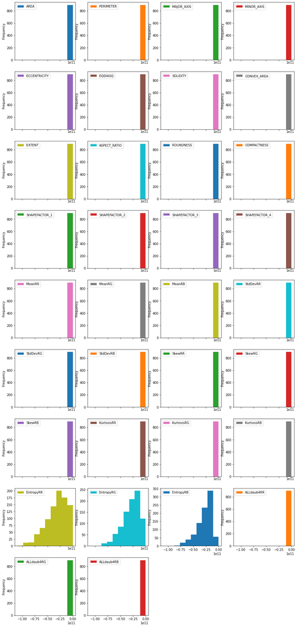

```python
# Histograms for each attribute
df_features_train.plot(kind='hist', subplots=True, layout=(display_rows, display_columns))
plt.show()
```

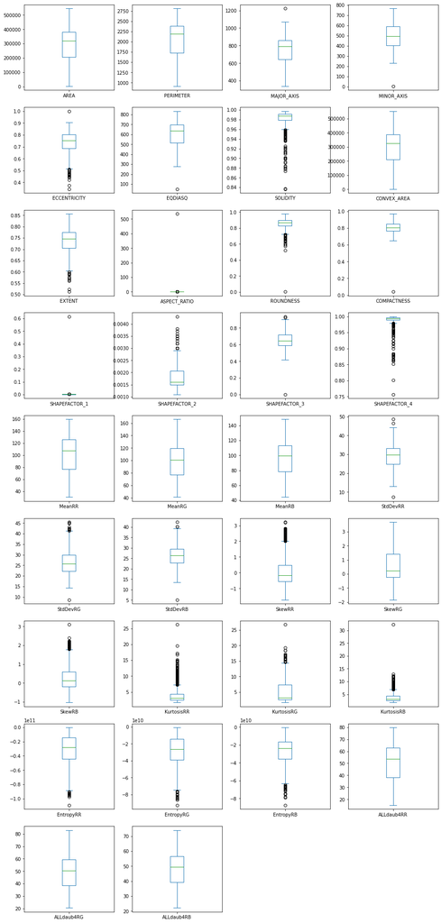

```python
# Box and Whisker plot for each attribute
df_features_train.plot(kind='box', subplots=True, layout=(display_rows, display_columns))
plt.show()
```

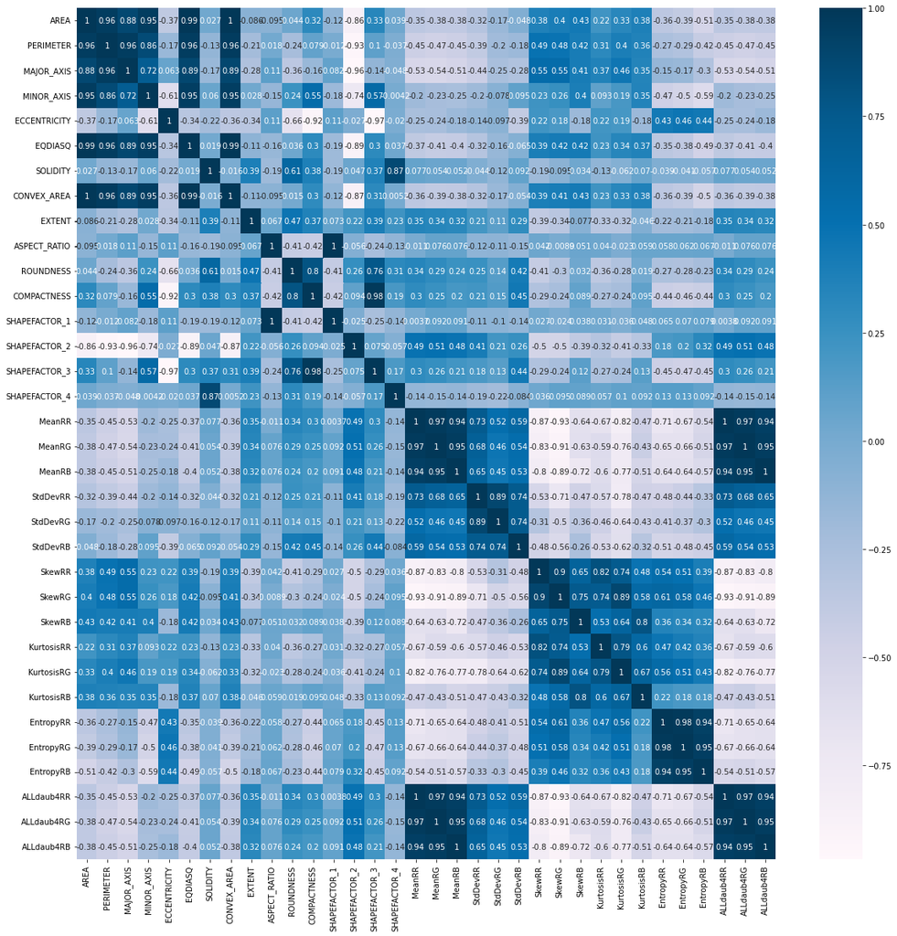

```python
# Correlation matrix
fig = plt.figure(figsize=(20, 20))
correlations = df_features_train.corr(method='pearson')
sns.heatmap(correlations, annot=True, cmap=plt.cm.PuBu)
plt.show()
```

```python
if NOTIFY_STATUS: status_notify("Task 2 - Summarize and Visualize Data completed! " + datetime.now().strftime('%a %B %d, %Y %I:%M:%S %p'))
```

## Task 3 - Pre-process Data

```python
if NOTIFY_STATUS: status_notify("Task 3 - Pre-process Data has begun! " + datetime.now().strftime('%a %B %d, %Y %I:%M:%S %p'))
```

### 3.a) Feature Scaling

```python
# Compose pipeline for the numerical and categorical features (Block #1 of 2)
numeric_columns = df_features_train.select_dtypes(include=['int','float']).columns
numeric_transformer = Pipeline(steps=[
    ('imputer', impute.SimpleImputer(strategy="constant", fill_value=0)),
    ('scaler', preprocessing.StandardScaler())
])
categorical_columns = df_features_train.select_dtypes(include=['object','bool','category']).columns
categorical_transformer = Pipeline(steps=[
    ('imputer', impute.SimpleImputer(strategy='constant', fill_value='UKNOWN')),
    ('onehot', preprocessing.OneHotEncoder(sparse=False, handle_unknown='ignore'))
])

print("Number of numerical columns:", len(numeric_columns))
print("Number of categorical columns:", len(categorical_columns))
print("Total number of columns in the feature dataframe:", df_features_train.shape[1])
```

```
Number of numerical columns: 34
Number of categorical columns: 0
Total number of columns in the feature dataframe: 34
```

```python
# Compose pipeline for the numerical and categorical features (Block #2 of 2)
preprocessor = compose.ColumnTransformer(transformers=[
    ('num', numeric_transformer, numeric_columns),
    ('cat', categorical_transformer, categorical_columns)
    ], remainder='passthrough')

# Display the shapes of the training dataset for final inspection
array_features_train = preprocessor.fit_transform(df_features_train)
print("Transformed features from df_features_train.shape: {} to array_features_train.shape: {}".format(df_features_train.shape, array_features_train.shape))
```

```
Transformed features from df_features_train.shape: (898, 34) to array_features_train.shape: (898, 34)
```

### 3.b) Training Data Balancing

```python
# Not applicable for this iteration of the project
```

### 3.c) Feature Selection

```python
# Not applicable for this iteration of the project
```

### 3.d) Display the Final Datasets for Model-Building

```python
# Finalize the training dataset for the modeling activities
array_features_train = preprocessor.fit_transform(df_features_train)
label_encoder = preprocessing.LabelEncoder()
array_target_train = label_encoder.fit_transform(df_target_train)
print("array_features_train.shape: {} array_target_train.shape: {}".format(array_features_train.shape, array_target_train.shape))
```

```
array_features_train.shape: (898, 34) array_target_train.shape: (898,)
```

```python
if NOTIFY_STATUS: status_notify("Task 3 - Pre-process Data completed! " + datetime.now().strftime('%a %B %d, %Y %I:%M:%S %p'))
```

## Task 4 - Train and Tune Models

```python
if NOTIFY_STATUS: status_notify("Task 4 - Train and Tune Models has begun! " + datetime.now().strftime('%a %B %d, %Y %I:%M:%S %p'))
```

### 4.a) Set test options and evaluation metric

```python
# Set up Algorithms Spot-Checking Array
start_time_training = datetime.now()
train_models = []
train_results = []
train_model_names = []
train_metrics = []
```

```python
train_models.append(('XGB', XGBClassifier(random_state=RNG_SEED, n_jobs=N_JOBS, objective='multi:softmax', use_label_encoder=False, eval_metric='mlogloss', tree_method='gpu_hist')))
```

```python
# Generate model in turn
for name, model in train_models:
    if NOTIFY_STATUS: status_notify("Algorithm "+name+" modeling has begun! " + datetime.now().strftime('%a %B %d, %Y %I:%M:%S %p'))
    start_time_module = datetime.now()
    kfold = StratifiedKFold(n_splits=N_FOLDS, shuffle=True, random_state=RNG_SEED)
    cv_results = cross_val_score(model, array_features_train, array_target_train, cv=kfold, scoring=SCORING_METRIC, n_jobs=N_JOBS, verbose=1)
    train_results.append(cv_results)
    train_model_names.append(name)
    train_metrics.append(cv_results.mean())
    print("%s: %f (%f)" % (name, cv_results.mean(), cv_results.std()))
    print(model)
    print ('Model training time:', (datetime.now() - start_time_module), '\n')
    if NOTIFY_STATUS: status_notify("Algorithm "+name+" modeling completed! " + datetime.now().strftime('%a %B %d, %Y %I:%M:%S %p'))
print ('Average metrics (' + SCORING_METRIC + ') from all models:', np.mean(train_metrics))
print ('Total training time for all models:', (datetime.now() - start_time_training))
```

```
[Parallel(n_jobs=1)]: Using backend SequentialBackend with 1 concurrent workers.
```

```
XGB: 0.894182 (0.012671)
XGBClassifier(eval_metric='mlogloss', objective='multi:softmax',
              random_state=888, tree_method='gpu_hist',
              use_label_encoder=False)
Model training time: 0:01:00.256828

Average metrics (accuracy) from all models: 0.8941822721598001
Total training time for all models: 0:01:00.275102
```

```
[Parallel(n_jobs=1)]: Done  10 out of  10 | elapsed:  1.0min finished
```

### 4.b) Algorithm Tuning

```python
# Set up the comparison array
tune_results = []
tune_model_names = []
```

```python
# Tuning XGBoost n_estimators, max_depth, and min_child_weight parameters
start_time_Module = datetime.now()
if NOTIFY_STATUS: status_notify("Algorithm tuning iteration #1 has begun! " + datetime.now().strftime('%a %B %d, %Y %I:%M:%S %p'))

tune_model1 = XGBClassifier(random_state=RNG_SEED, n_jobs=N_JOBS, objective='multi:softprob', use_label_encoder=False, eval_metric='mlogloss', tree_method='gpu_hist')
tune_model_names.append('XGB_1')
paramGrid1 = dict(n_estimators=range(100, 501, 100),
                  max_depth=np.array([3, 6, 9]),
                  min_child_weight=np.array([1, 2, 3]))

kfold = StratifiedKFold(n_splits=N_FOLDS, shuffle=True, random_state=RNG_SEED)
grid1 = GridSearchCV(estimator=tune_model1, param_grid=paramGrid1, scoring=SCORING_METRIC, cv=kfold, n_jobs=N_JOBS, verbose=1)
grid_result1 = grid1.fit(array_features_train, array_target_train)

print("Best: %f using %s" % (grid_result1.best_score_, grid_result1.best_params_))
tune_results.append(grid_result1.cv_results_['mean_test_score'])
means = grid_result1.cv_results_['mean_test_score']
stds = grid_result1.cv_results_['std_test_score']
params = grid_result1.cv_results_['params']
for mean, stdev, param in zip(means, stds, params):
    print("%f (%f) with: %r" % (mean, stdev, param))
print ('Model training time:', (datetime.now() - start_time_Module))
if NOTIFY_STATUS: status_notify("Algorithm tuning iteration #1 completed! " + datetime.now().strftime('%a %B %d, %Y %I:%M:%S %p'))
```

```
Fitting 10 folds for each of 45 candidates, totalling 450 fits
Best: 0.903109 using {'max_depth': 9, 'min_child_weight': 1, 'n_estimators': 300}
0.894182 (0.012671) with: {'max_depth': 3, 'min_child_weight': 1, 'n_estimators': 100}
0.893046 (0.016262) with: {'max_depth': 3, 'min_child_weight': 1, 'n_estimators': 200}
0.895268 (0.015525) with: {'max_depth': 3, 'min_child_weight': 1, 'n_estimators': 300}
0.897491 (0.018199) with: {'max_depth': 3, 'min_child_weight': 1, 'n_estimators': 400}
0.898602 (0.019932) with: {'max_depth': 3, 'min_child_weight': 1, 'n_estimators': 500}
0.896392 (0.015301) with: {'max_depth': 3, 'min_child_weight': 2, 'n_estimators': 100}
0.896380 (0.016951) with: {'max_depth': 3, 'min_child_weight': 2, 'n_estimators': 200}
0.895268 (0.019728) with: {'max_depth': 3, 'min_child_weight': 2, 'n_estimators': 300}
0.897491 (0.021894) with: {'max_depth': 3, 'min_child_weight': 2, 'n_estimators': 400}
0.898602 (0.021710) with: {'max_depth': 3, 'min_child_weight': 2, 'n_estimators': 500}
0.890836 (0.014170) with: {'max_depth': 3, 'min_child_weight': 3, 'n_estimators': 100}
0.894157 (0.017059) with: {'max_depth': 3, 'min_child_weight': 3, 'n_estimators': 200}
0.896392 (0.013613) with: {'max_depth': 3, 'min_child_weight': 3, 'n_estimators': 300}
0.898614 (0.015678) with: {'max_depth': 3, 'min_child_weight': 3, 'n_estimators': 400}
0.898614 (0.016446) with: {'max_depth': 3, 'min_child_weight': 3, 'n_estimators': 500}
0.894182 (0.017570) with: {'max_depth': 6, 'min_child_weight': 1, 'n_estimators': 100}
0.895293 (0.017552) with: {'max_depth': 6, 'min_child_weight': 1, 'n_estimators': 200}
0.897516 (0.015009) with: {'max_depth': 6, 'min_child_weight': 1, 'n_estimators': 300}
0.898639 (0.014644) with: {'max_depth': 6, 'min_child_weight': 1, 'n_estimators': 400}
0.896417 (0.018751) with: {'max_depth': 6, 'min_child_weight': 1, 'n_estimators': 500}
0.895318 (0.014300) with: {'max_depth': 6, 'min_child_weight': 2, 'n_estimators': 100}
0.895293 (0.013587) with: {'max_depth': 6, 'min_child_weight': 2, 'n_estimators': 200}
0.896404 (0.012522) with: {'max_depth': 6, 'min_child_weight': 2, 'n_estimators': 300}
0.898627 (0.013875) with: {'max_depth': 6, 'min_child_weight': 2, 'n_estimators': 400}
0.897516 (0.014163) with: {'max_depth': 6, 'min_child_weight': 2, 'n_estimators': 500}
0.890849 (0.020504) with: {'max_depth': 6, 'min_child_weight': 3, 'n_estimators': 100}
0.893071 (0.016799) with: {'max_depth': 6, 'min_child_weight': 3, 'n_estimators': 200}
0.894182 (0.019593) with: {'max_depth': 6, 'min_child_weight': 3, 'n_estimators': 300}
0.894195 (0.018853) with: {'max_depth': 6, 'min_child_weight': 3, 'n_estimators': 400}
0.891960 (0.020641) with: {'max_depth': 6, 'min_child_weight': 3, 'n_estimators': 500}
0.900874 (0.016207) with: {'max_depth': 9, 'min_child_weight': 1, 'n_estimators': 100}
0.901998 (0.014800) with: {'max_depth': 9, 'min_child_weight': 1, 'n_estimators': 200}
0.903109 (0.015024) with: {'max_depth': 9, 'min_child_weight': 1, 'n_estimators': 300}
0.900874 (0.014566) with: {'max_depth': 9, 'min_child_weight': 1, 'n_estimators': 400}
0.900874 (0.014566) with: {'max_depth': 9, 'min_child_weight': 1, 'n_estimators': 500}
0.894195 (0.016774) with: {'max_depth': 9, 'min_child_weight': 2, 'n_estimators': 100}
0.895293 (0.014467) with: {'max_depth': 9, 'min_child_weight': 2, 'n_estimators': 200}
0.897516 (0.016573) with: {'max_depth': 9, 'min_child_weight': 2, 'n_estimators': 300}
0.895293 (0.017552) with: {'max_depth': 9, 'min_child_weight': 2, 'n_estimators': 400}
0.897516 (0.019324) with: {'max_depth': 9, 'min_child_weight': 2, 'n_estimators': 500}
0.890849 (0.016467) with: {'max_depth': 9, 'min_child_weight': 3, 'n_estimators': 100}
0.890849 (0.017200) with: {'max_depth': 9, 'min_child_weight': 3, 'n_estimators': 200}
0.894182 (0.018259) with: {'max_depth': 9, 'min_child_weight': 3, 'n_estimators': 300}
0.894182 (0.019565) with: {'max_depth': 9, 'min_child_weight': 3, 'n_estimators': 400}
0.893071 (0.017518) with: {'max_depth': 9, 'min_child_weight': 3, 'n_estimators': 500}
Model training time: 0:17:20.178208
```

```python
BEST_MAX_DEPTH = grid_result1.best_params_['max_depth']
BEST_MIN_CHILD_WEIGHT = grid_result1.best_params_['min_child_weight']
BEST_N_ESTIMATORS = grid_result1.best_params_['n_estimators']
print('Best max_depth parameter:', BEST_MAX_DEPTH)
print('Best min_child_weight parameter:', BEST_MIN_CHILD_WEIGHT)
print('Best n_estimators parameter:', BEST_N_ESTIMATORS)
```

```
Best max_depth parameter: 9
Best min_child_weight parameter: 1
Best n_estimators parameter: 300
```

```python
# Tuning XGBoost subsample and colsample_bytree parameters
start_time_Module = datetime.now()
if NOTIFY_STATUS: status_notify("Algorithm tuning iteration #2 has begun! " + datetime.now().strftime('%a %B %d, %Y %I:%M:%S %p'))

tune_model2 = XGBClassifier(n_estimators=BEST_N_ESTIMATORS, max_depth=BEST_MAX_DEPTH, min_child_weight=BEST_MIN_CHILD_WEIGHT,
                            random_state=RNG_SEED, n_jobs=N_JOBS, objective='multi:softprob', use_label_encoder=False, eval_metric='mlogloss', tree_method='gpu_hist')
tune_model_names.append('XGB_2')
paramGrid2 = dict(subsample=np.array([0.7, 0.8, 0.9, 1.0]),
                  colsample_bytree=np.array([0.7, 0.8, 0.9, 1.0]))

kfold = StratifiedKFold(n_splits=N_FOLDS, shuffle=True, random_state=RNG_SEED)
grid2 = GridSearchCV(estimator=tune_model2, param_grid=paramGrid2, scoring=SCORING_METRIC, cv=kfold, n_jobs=N_JOBS, verbose=1)
grid_result2 = grid2.fit(array_features_train, array_target_train)

print("Best: %f using %s" % (grid_result2.best_score_, grid_result2.best_params_))
tune_results.append(grid_result2.cv_results_['mean_test_score'])
means = grid_result2.cv_results_['mean_test_score']
stds = grid_result2.cv_results_['std_test_score']
params = grid_result2.cv_results_['params']
for mean, stdev, param in zip(means, stds, params):
    print("%f (%f) with: %r" % (mean, stdev, param))
print ('Model training time:',(datetime.now() - start_time_Module))
if NOTIFY_STATUS: status_notify("Algorithm tuning iteration #2 completed! " + datetime.now().strftime('%a %B %d, %Y %I:%M:%S %p'))
```

```
Fitting 10 folds for each of 16 candidates, totalling 160 fits
Best: 0.907541 using {'colsample_bytree': 1.0, 'subsample': 0.9}
0.900861 (0.023679) with: {'colsample_bytree': 0.7, 'subsample': 0.7}
0.896429 (0.024899) with: {'colsample_bytree': 0.7, 'subsample': 0.8}
0.898614 (0.017164) with: {'colsample_bytree': 0.7, 'subsample': 0.9}
0.898639 (0.017698) with: {'colsample_bytree': 0.7, 'subsample': 1.0}
0.896417 (0.024953) with: {'colsample_bytree': 0.8, 'subsample': 0.7}
0.900861 (0.018412) with: {'colsample_bytree': 0.8, 'subsample': 0.8}
0.900849 (0.016363) with: {'colsample_bytree': 0.8, 'subsample': 0.9}
0.898627 (0.014738) with: {'colsample_bytree': 0.8, 'subsample': 1.0}
0.895293 (0.020170) with: {'colsample_bytree': 0.9, 'subsample': 0.7}
0.891960 (0.023442) with: {'colsample_bytree': 0.9, 'subsample': 0.8}
0.899738 (0.018837) with: {'colsample_bytree': 0.9, 'subsample': 0.9}
0.899750 (0.015100) with: {'colsample_bytree': 0.9, 'subsample': 1.0}
0.900861 (0.018397) with: {'colsample_bytree': 1.0, 'subsample': 0.7}
0.899763 (0.021754) with: {'colsample_bytree': 1.0, 'subsample': 0.8}
0.907541 (0.017474) with: {'colsample_bytree': 1.0, 'subsample': 0.9}
0.903109 (0.015024) with: {'colsample_bytree': 1.0, 'subsample': 1.0}
Model training time: 0:06:52.546718
```

```python
BEST_COLSAMPLE_BYTREE = grid_result2.best_params_['colsample_bytree']
BEST_SUBSAMPLE = grid_result2.best_params_['subsample']
print('Best colsample_bytree parameter:', BEST_COLSAMPLE_BYTREE)
print('Best subsample parameter:', BEST_SUBSAMPLE)
```

```
Best colsample_bytree parameter: 1.0
Best subsample parameter: 0.9
```

### 4.c) Compare Algorithms After Tuning

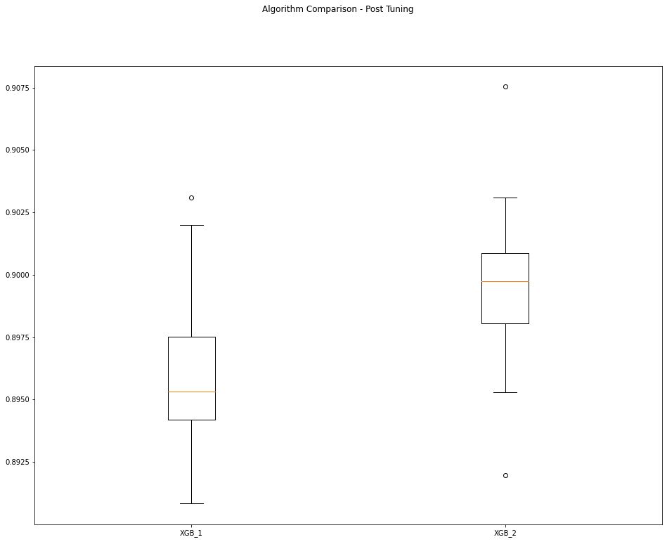

```python
fig = plt.figure(figsize=(16,12))
fig.suptitle('Algorithm Comparison - Post Tuning')
ax = fig.add_subplot(111)
plt.boxplot(tune_results)
ax.set_xticklabels(tune_model_names)
plt.show()
```

```python
if NOTIFY_STATUS: status_notify("Task 4 - Train and Tune Models completed! " + datetime.now().strftime('%a %B %d, %Y %I:%M:%S %p'))
```

## Task 5 - Finalize Model and Make Predictions

```python
if NOTIFY_STATUS: status_notify("Task 5 - Finalize Model and Make Predictions has begun! " + datetime.now().strftime('%a %B %d, %Y %I:%M:%S %p'))
```

```python
final_model = XGBClassifier(n_estimators=BEST_N_ESTIMATORS, max_depth=BEST_MAX_DEPTH, min_child_weight=BEST_MIN_CHILD_WEIGHT,
                            colsample_bytree=BEST_COLSAMPLE_BYTREE, subsample=BEST_SUBSAMPLE, random_state=RNG_SEED,
                            n_jobs=N_JOBS, objective='multi:softprob', use_label_encoder=False, eval_metric='mlogloss', tree_method='gpu_hist')
final_model.fit(array_features_train, array_target_train)
print(final_model)
```

```
XGBClassifier(colsample_bytree=1.0, eval_metric='mlogloss', max_depth=9,
              n_estimators=300, objective='multi:softprob', random_state=888,
              subsample=0.9, tree_method='gpu_hist', use_label_encoder=False)
```

```python
if NOTIFY_STATUS: status_notify("Task 5 - Finalize Model and Make Predictions completed! " + datetime.now().strftime('%a %B %d, %Y %I:%M:%S %p'))
```

```python
print ('Total time for the script:',(datetime.now() - START_TIME_SCRIPT))
```

```
Total time for the script: 0:25:32.396754
```